# Prescriptive Analytics in Property Management: An Example with HVAC Telemetry

Author

Joël R. Pradines, Ph.D.

Published

September 19, 2026

# 1. Data Ingestion and Exploration

```
Rows: 33,888
Columns: 11
$ timestamp    <dttm> 2019-10-14 22:00:00, 2019-10-14 22:15:00, 2019-10-14 22:…
$ t_supply     <dbl> 19.860, 19.855, 19.850, 19.840, 19.830, 19.830, 19.835, 1…
$ t_return     <dbl> 20.470, 20.430, 20.410, 20.380, 20.350, 20.320, 20.310, 2…
$ sp_return    <dbl> 18.5, 18.5, 18.5, 18.5, 18.5, 18.5, 18.5, 18.5, 18.5, 18.…
$ t_saturation <dbl> 19.02, 19.02, 19.02, 19.08, 19.08, 19.10, 19.12, 19.14, 1…
$ t_outdoor    <dbl> 20.3, 20.3, 20.3, 20.3, 20.3, 20.3, 19.3, 19.3, 19.3, 19.…
$ rh_supply    <dbl> 71.11, 71.32, 71.47, 71.44, 71.58, 71.60, 71.66, 71.71, 7…
$ rh_return    <dbl> 58.92, 59.00, 59.11, 59.31, 59.56, 59.66, 59.76, 59.90, 6…
$ rh_outdoor   <dbl> 79.5, 82.0, 79.5, 77.0, 79.5, 82.0, 85.0, 88.0, 85.0, 82.…
$ energy       <dbl> 0, 0, 0, 0, 0, 0, 0, 0, 0, 0, 0, 0, 0, 0, 0, 0, 0, 0, 0, …
$ power        <dbl> 0, 0, 0, 0, 0, 0, 0, 0, 0, 0, 0, 0, 0, 0, 0, 0, 0, 0, 0, …
```

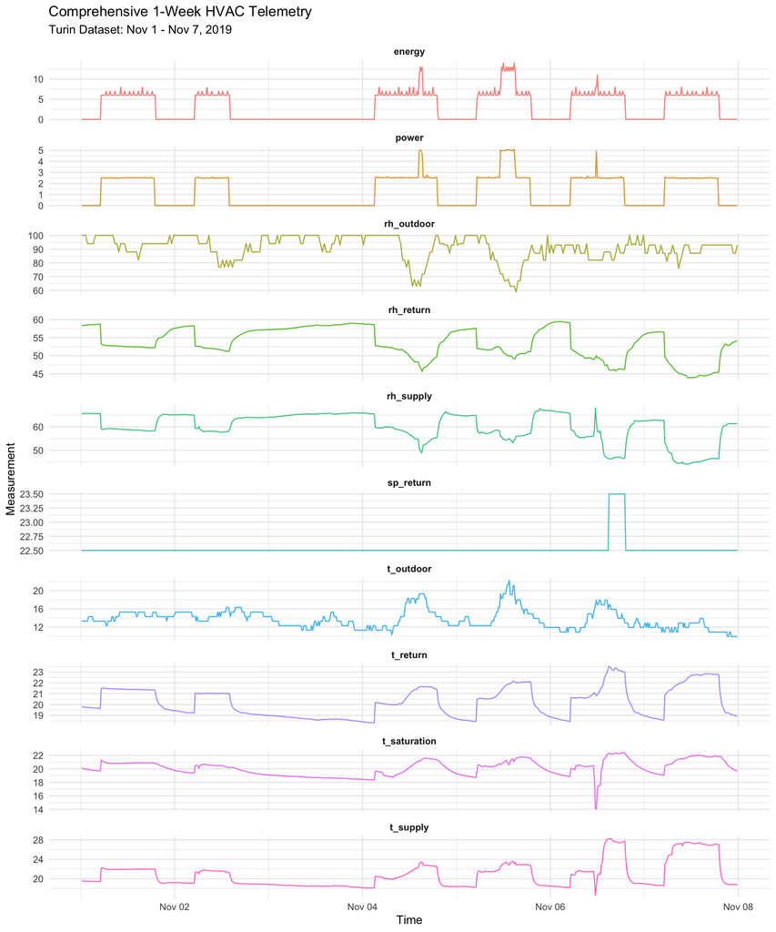

Figure 1: 1-Week Time Course of All System Variables

- `power`: The power required by the fans [kW]. This is the instantaneous electrical demand. It shows a “block” pattern, representing the fan motors turning on, running at a steady state, and shutting off.
- `energy`: The energy required by the fans [kWh]. Power is the instantaneous rate, energy is the accumulated electricity consumed. The jagged, sawtooth pattern on top of the blocks is characteristic of accumulation over a 15-minute intervals.
- `rh_outdoor` (Outdoor Relative Humidity): The relative humidity of the outside air [%]. It dips during the warmest part of the day and peaks at night when the air cools.
- `rh_return` (Return Relative Humidity): The relative humidity of the return air [%]. Heating a volume of air lowers its relative humidity: every time the system turns on to heat the space (`power`, `energy`), this indoor humidity drops.
- `rh_supply` (Supply Relative Humidity): The relative humidity of the supply air [%]. It tends to mirrors the return humidity but is physically altered by the heating coils.
- `sp_return (Setpoint Return)`: Tthe temperature setpoint of the return air [°C]. It represents the target temperature for the rooms.
- `t_outdoor (Outdoor Temperature)`: The ambient temperature outside [°C]. Natural diurnal (day/night) weather cycles.
- `t_return` (Return Temperature): The temperature of the air pulled back from the rooms into the HVAC unit [°C]: proxy for the actual room temperature.
- `t_saturation` (Saturation Temperature): The saturation temperature in the humidifier [°C]. Relates to the dew point the system maintains to prevent the air from becoming too dry when heated.
- `t_supply` (Supply Temperature): The temperature of the conditioned air being pushed into the rooms [°C]. To change the room temperature (t_return) to the target (sp_return), the system has to blast much warmer/colder air.

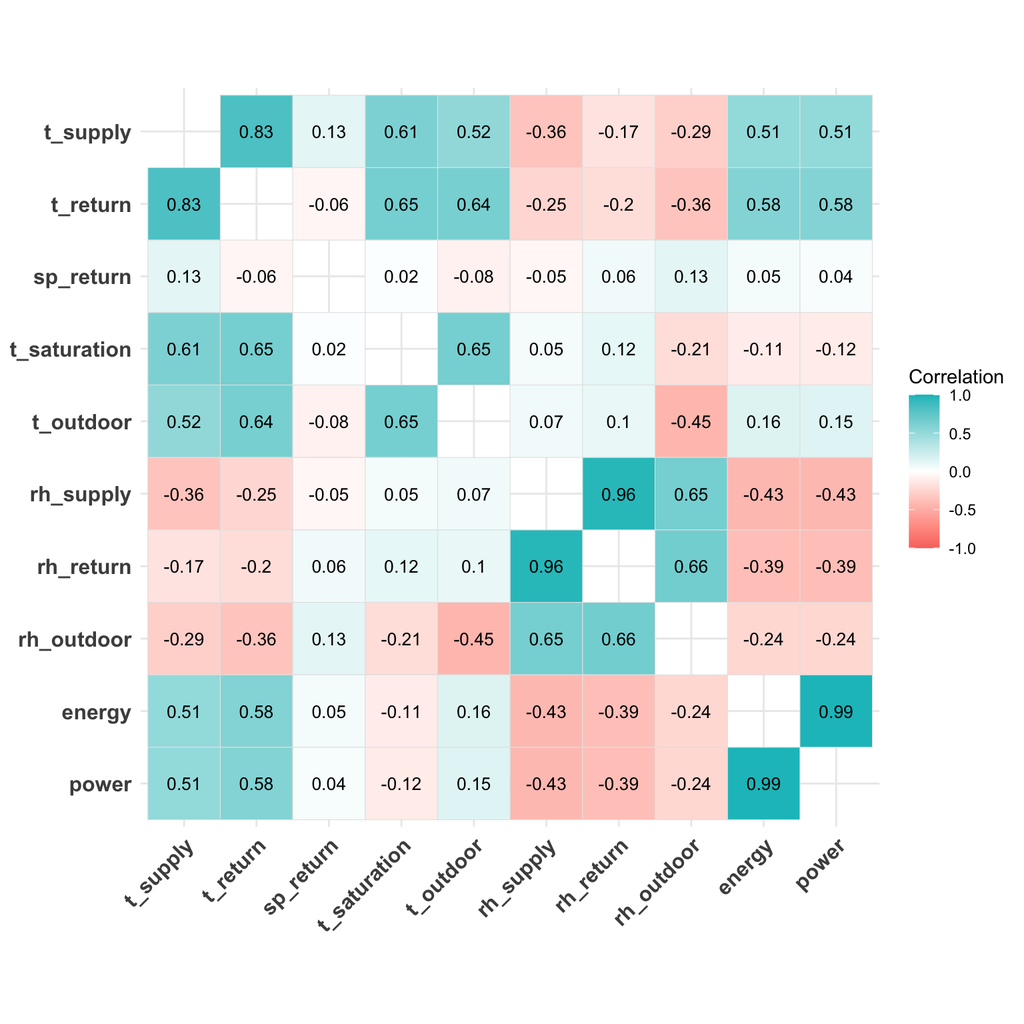

Figure 2: Global Pearson correlation heatmap (Full Turin Dataset)

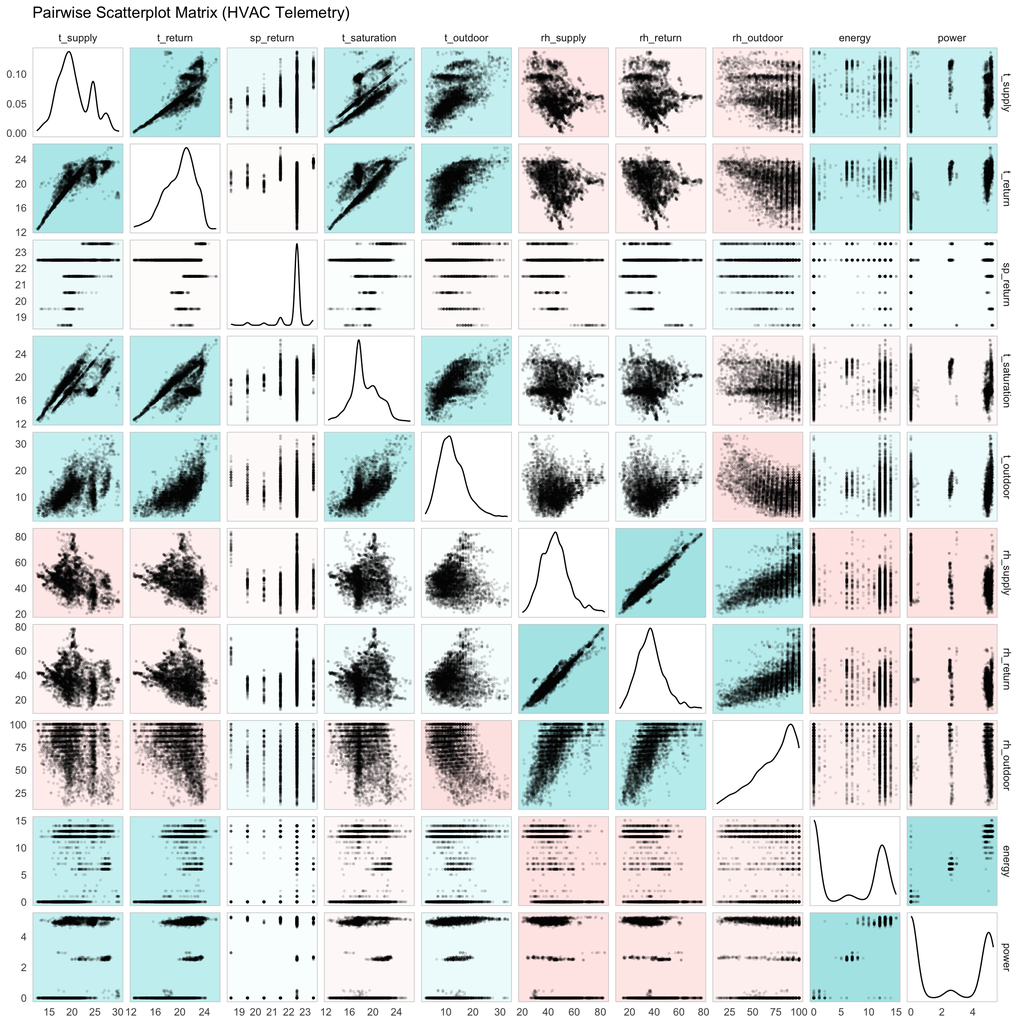

Figure 3: Scatterplot matrix with correlation-mapped backgrounds (Sampled at n=5000)

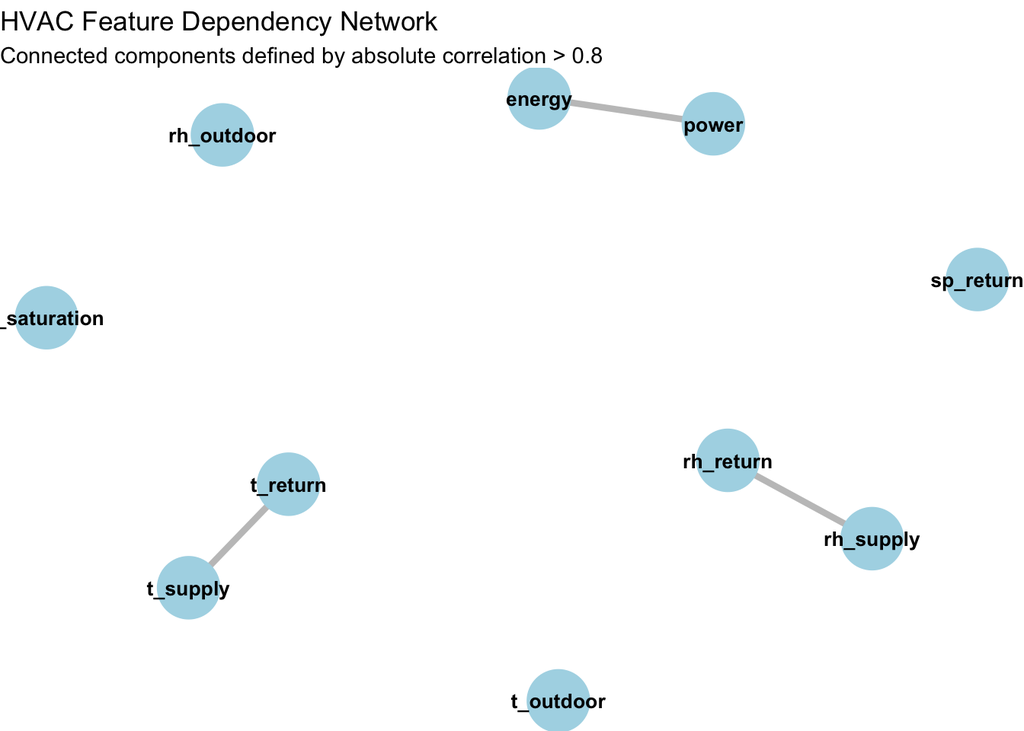

Figure 4: HVAC feature dependency network representing highly collinear clusters

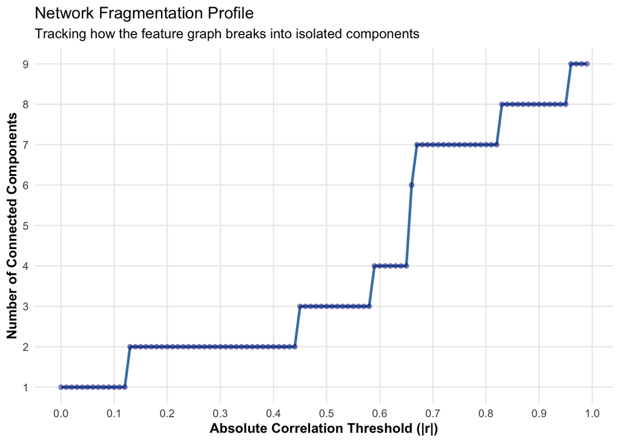

Figure 5: Network fragmentation across correlation thresholds

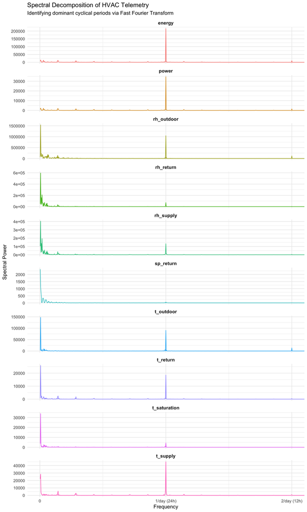

Figure 6: Power Spectral Density (Frequency Domain)

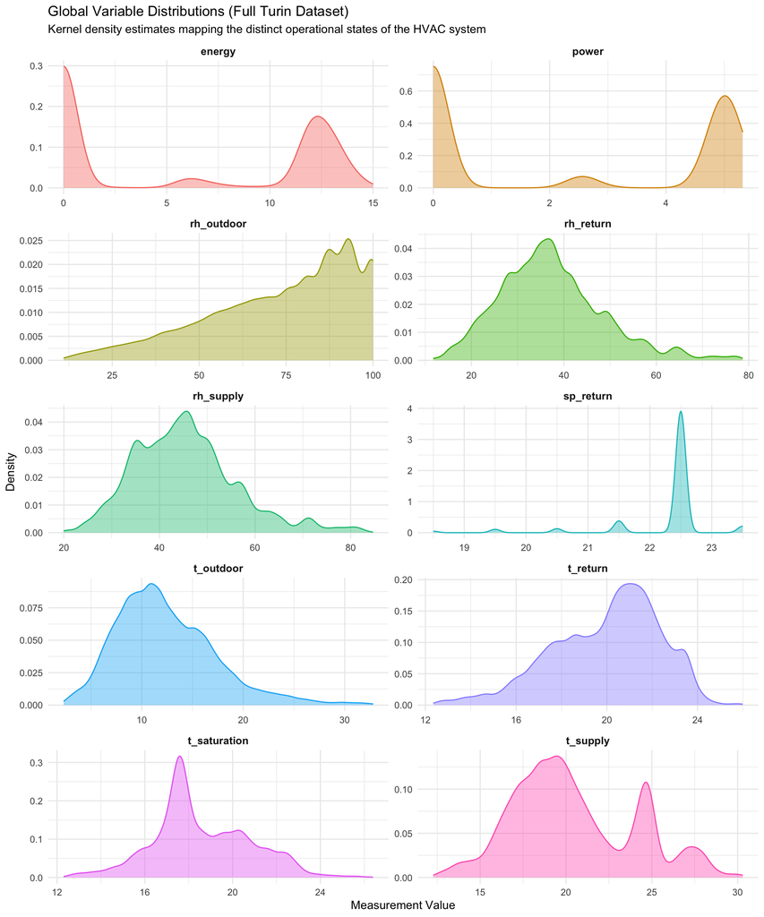

Figure 7: Global density distributions of HVAC telemetry (Low bandwidth KDE)

`power`: drop

`time_stamp`

`is_weekend` (from time_stamp)

`energy` (Raw State)

`energy_lag_24h` (Schedule context)

`energy_deriv_15m` (State transition context)

`rh_outdoor` (Raw context)

`rh_outdoor_lag_24h` (Weather shifts)

`delta_rh` = `rh_return` - `rh_supply` (The active moisture control work)

`delta_rh_deriv_15m` (Sudden state changes in moisture control)

`t_outdoor` (Raw weather)

`t_outdoor_lag_24h` (Weather shift)

`t_saturation` (Raw state)

`t_saturation_deriv_15m` (Sudden humidifier faults)

`delta_t` = `t_return` - `t_supply` (The active heating work):

`delta_t_deriv_15m` (Sudden loss or surge of heating power)

`temp_error` (How far off target the building is) $t\_return - sp\_return$

`sp_return`

```r
library(dplyr)
library(tidyr)
library(lubridate)
library(slider)

hvac_features <- hvac_clean %>%
  # 0. Catch any stray NAs in the timestamp column before sequencing
  filter(!is.na(timestamp)) %>%
  # 1. Ensure the data is perfectly continuous in 15-minute increments
  complete(
    timestamp = seq(
      min(timestamp, na.rm = TRUE),
      max(timestamp, na.rm = TRUE),
      by = "15 mins"
    )
  ) %>%
  arrange(timestamp) %>%
  mutate(
    # 2. Context & Control
    is_weekend = if_else(wday(timestamp, week_start = 1) %in% c(6, 7), 1, 0),
    temp_error = t_return - sp_return,

    # 3. Common-Mode Rejection (Physics)
    delta_t = t_return - t_supply,
    delta_rh = rh_return - rh_supply
  ) %>%
  mutate(
    # 4. Cyclical Lags
    t_outdoor_lag_24h = t_outdoor - lag(t_outdoor, n = 96),
    rh_outdoor_lag_24h = rh_outdoor - lag(rh_outdoor, n = 96),
    energy_lag_24h = energy - lag(energy, n = 96),

    # 5. Instantaneous Derivatives
    energy_deriv_15m = energy - lag(energy, n = 1),
    delta_t_deriv_15m = delta_t - lag(delta_t, n = 1),
    delta_rh_deriv_15m = delta_rh - lag(delta_rh, n = 1),
    t_return_deriv_15m = t_return - lag(t_return, n = 1),
    t_saturation_deriv_15m = t_saturation - lag(t_saturation, n = 1),

    # 6. Volatility
    t_supply_roll_sd_1h = slider::slide_dbl(t_supply, sd, .before = 3, .complete = TRUE)
  ) %>%
  # 7. Purge all artifacts (including the summer gap NAs)
  drop_na()

glimpse(hvac_features)
```

```
Rows: 31,744
Columns: 24
$ timestamp              <dttm> 2019-10-15 22:00:00, 2019-10-15 22:15:00, 2019…
$ t_supply               <dbl> 19.040, 19.015, 18.985, 18.945, 18.930, 18.920,…
$ t_return               <dbl> 19.785, 19.735, 19.705, 19.655, 19.615, 19.595,…
$ sp_return              <dbl> 18.5, 18.5, 18.5, 18.5, 18.5, 18.5, 18.5, 18.5,…
$ t_saturation           <dbl> 18.50, 18.54, 18.56, 18.60, 18.60, 18.60, 18.60…
$ t_outdoor              <dbl> 17.3, 16.3, 16.3, 16.3, 16.3, 16.3, 16.3, 16.3,…
$ rh_supply              <dbl> 81.750, 81.740, 81.780, 81.590, 81.740, 82.130,…
$ rh_return              <dbl> 70.10, 70.17, 70.29, 70.42, 70.49, 70.56, 70.59…
$ rh_outdoor             <dbl> 97, 94, 97, 100, 97, 94, 94, 94, 94, 94, 94, 94…
$ energy                 <dbl> 0, 0, 0, 0, 0, 0, 0, 0, 0, 0, 0, 0, 0, 0, 0, 0,…
$ power                  <dbl> 0.000, 0.000, 0.000, 0.000, 0.000, 0.000, 0.000…
$ is_weekend             <dbl> 0, 0, 0, 0, 0, 0, 0, 0, 0, 0, 0, 0, 0, 0, 0, 0,…
$ temp_error             <dbl> 1.285000, 1.234999, 1.205000, 1.154999, 1.11500…
$ delta_t                <dbl> 0.745001, 0.720000, 0.720001, 0.709999, 0.68500…
$ delta_rh               <dbl> -11.650002, -11.570000, -11.489998, -11.169998,…
$ t_outdoor_lag_24h      <dbl> -3.000000, -4.000000, -4.000000, -4.000000, -4.…
$ rh_outdoor_lag_24h     <dbl> 17.5, 12.0, 17.5, 23.0, 17.5, 12.0, 9.0, 6.0, 6…
$ energy_lag_24h         <dbl> 0, 0, 0, 0, 0, 0, 0, 0, 0, 0, 0, 0, 0, 0, 0, 0,…
$ energy_deriv_15m       <dbl> 0, 0, 0, 0, 0, 0, 0, 0, 0, 0, 0, 0, 0, 0, 0, 0,…
$ delta_t_deriv_15m      <dbl> -0.019999, -0.025001, 0.000001, -0.010002, -0.0…
$ delta_rh_deriv_15m     <dbl> 0.019996, 0.080002, 0.080002, 0.320000, -0.0800…
$ t_return_deriv_15m     <dbl> -0.039999, -0.050001, -0.029999, -0.050001, -0.…
$ t_saturation_deriv_15m <dbl> 0.000000, 0.039999, 0.020000, 0.040001, 0.00000…
$ t_supply_roll_sd_1h    <dbl> 0.02327373, 0.02598076, 0.03240370, 0.04090089,…
```

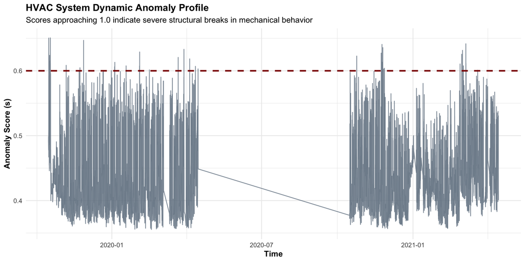

Isolation Forest Anomaly Scores over Time

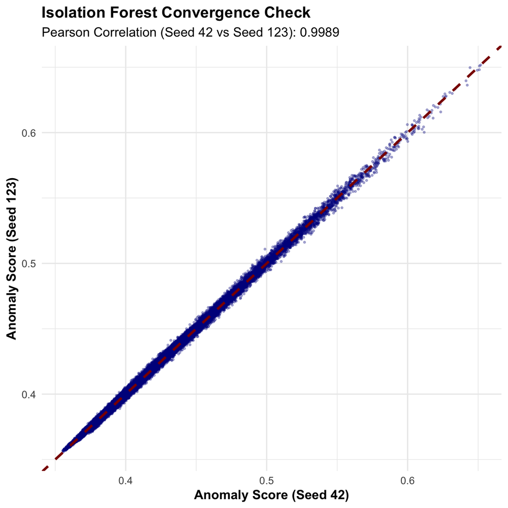

Stability Check: Anomaly Scores across Random Seeds

```r
library(ggplot2)
library(dplyr)

# 1. Fit Model A
iso_model_A <- isolation.forest(
  train_data,
  ntrees = 500,
  sample_size = 256,
  missing_action = "fail",
  seed = 42
)

# 2. Fit Model B
iso_model_B <- isolation.forest(
  train_data,
  ntrees = 500,
  sample_size = 256,
  missing_action = "fail",
  seed = 123
)

# 3. Score and Combine
qc_data <- tibble(
  score_A = predict(iso_model_A, train_data),
  score_B = predict(iso_model_B, train_data)
)

# 4. Calculate Convergence Metric
stability_cor <- cor(qc_data$score_A, qc_data$score_B)

# 5. Visualize the Variance
ggplot(qc_data, aes(x = score_A, y = score_B)) +
  geom_point(alpha = 0.3, size = 0.5, color = "darkblue") +
  # Reference line for perfect agreement
  geom_abline(intercept = 0, slope = 1, color = "darkred", linetype = "dashed", linewidth = 1) +
  theme_minimal() +
  labs(
    title = "Isolation Forest Convergence Check",
    subtitle = sprintf("Pearson Correlation (Seed 42 vs Seed 123): %.4f", stability_cor),
    x = "Anomaly Score (Seed 42)",
    y = "Anomaly Score (Seed 123)"
  ) +
  theme(
    axis.title = element_text(face = "bold"),
    plot.title = element_text(face = "bold")
  )
```

```
# A tibble: 5 × 8
  timestamp           anomaly_score is_weekend sp_return temp_error
  <dttm>                      <dbl>      <dbl>     <dbl>      <dbl>
1 2019-10-18 05:15:00         0.651          0      18.5      3.20
2 2019-10-16 07:15:00         0.651          0      18.5      2.54
3 2019-10-18 06:30:00         0.650          0      18.5      2.91
4 2019-11-27 16:00:00         0.647          0      23.5     -0.305
5 2021-03-06 05:15:00         0.642          1      19.5      1.77
# ℹ 3 more variables: energy_deriv_15m <dbl>, delta_t <dbl>,
#   delta_t_deriv_15m <dbl>
```

```
# A tibble: 5 × 7
  timestamp           anomaly_score   p_value is_weekend sp_return temp_error
  <dttm>                      <dbl>     <dbl>      <dbl>     <dbl>      <dbl>
1 2019-10-18 05:15:00         0.651 0                  0      18.5      3.20
2 2019-10-16 07:15:00         0.651 0.0000315          0      18.5      2.54
3 2019-10-18 06:30:00         0.650 0.0000630          0      18.5      2.91
4 2019-11-27 16:00:00         0.647 0.0000945          0      23.5     -0.305
5 2021-03-06 05:15:00         0.642 0.000126           1      19.5      1.77
# ℹ 1 more variable: delta_t <dbl>
```

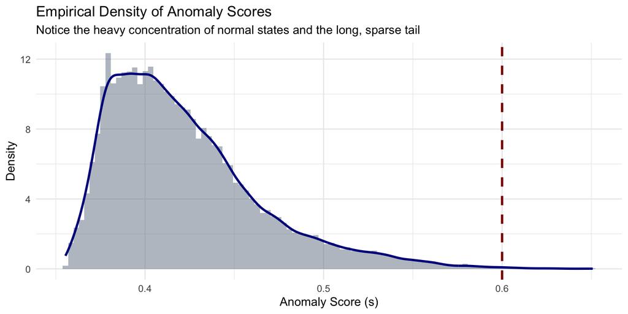

Density Distribution of Isolation Forest Scores

```r
ggplot(hvac_scored, aes(x = anomaly_score)) +
  geom_histogram(aes(y = after_stat(density)), bins = 100, fill = "slategray", alpha = 0.5) +
  geom_density(color = "darkblue", linewidth = 1) +
  geom_vline(xintercept = 0.6, linetype = "dashed", color = "darkred", linewidth = 1) +
  theme_minimal() +
  labs(
    title = "Empirical Density of Anomaly Scores",
    subtitle = "Notice the heavy concentration of normal states and the long, sparse tail",
    x = "Anomaly Score (s)",
    y = "Density"
  )
```

```r
library(MASS)
library(ggplot2)

# 1. Calculate Method of Moments (MoM) to use as starting values for MLE
scores <- hvac_scored$anomaly_score
mu <- mean(scores)
var_x <- var(scores)

alpha_mom <- mu * ((mu * (1 - mu) / var_x) - 1)
beta_mom <- (1 - mu) * ((mu * (1 - mu) / var_x) - 1)

# 2. Fit the Beta distribution using Maximum Likelihood Estimation
beta_mle <- fitdistr(
  scores,
  densfun = "beta",
  start = list(shape1 = alpha_mom, shape2 = beta_mom)
)

alpha_est <- beta_mle$estimate["shape1"]
beta_est <- beta_mle$estimate["shape2"]

cat(sprintf("MLE Estimates:\nAlpha: %.4f\nBeta: %.4f\n\n", alpha_est, beta_est))
```

```
MLE Estimates:
Alpha: 57.0388
Beta: 77.9877
```

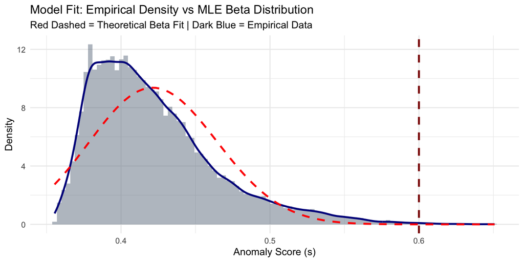

Empirical Density vs MLE Beta Distribution

```r
# 3. Superimpose the theoretical Beta curve on the empirical data
ggplot(hvac_scored, aes(x = anomaly_score)) +
  geom_histogram(aes(y = after_stat(density)), bins = 100, fill = "slategray", alpha = 0.5) +
  # Empirical Density (Dark Blue)
  geom_density(color = "darkblue", linewidth = 1) +
  # Theoretical Beta Density (Bright Red Dashed)
  stat_function(
    fun = dbeta,
    args = list(shape1 = alpha_est, shape2 = beta_est),
    color = "red",
    linetype = "dashed",
    linewidth = 1
  ) +
  geom_vline(xintercept = 0.6, linetype = "dashed", color = "darkred", linewidth = 1) +
  theme_minimal() +
  labs(
    title = "Model Fit: Empirical Density vs MLE Beta Distribution",
    subtitle = "Red Dashed = Theoretical Beta Fit | Dark Blue = Empirical Data",
    x = "Anomaly Score (s)",
    y = "Density"
  )
```

```
# A tibble: 3 × 6
  fault_signature event_count avg_temp_error avg_delta_t avg_energy_surge
  <fct>                 <int>          <dbl>       <dbl>            <dbl>
1 1                        18          1.97         4.36             3.39
2 2                        18          0.139       -1.90            -7.11
3 3                        16         -3.46        -8.06            -1.5
# ℹ 1 more variable: avg_volatility <dbl>
```

```r
# install.packages("cluster") # Run in console if needed
library(cluster)

# 1. Run Divisive Analysis (Top-Down)
diana_model <- diana(cluster_scaled, metric = "euclidean")

# 2. Cut the divisive tree into 3 distinct fault signatures
severe_anomalies <- severe_anomalies %>%
  mutate(fault_signature_diana = as.factor(cutree(as.hclust(diana_model), k = 3)))

# 3. Summarize the mechanical profile of the new DIANA signatures
fault_profiles_diana <- severe_anomalies %>%
  group_by(fault_signature_diana) %>%
  summarize(
    event_count = n(),
    avg_temp_error = mean(temp_error, na.rm = TRUE),
    avg_delta_t = mean(delta_t, na.rm = TRUE),
    avg_energy_surge = mean(energy_deriv_15m, na.rm = TRUE),
    avg_volatility = mean(t_supply_roll_sd_1h, na.rm = TRUE)
  )

# Compare this output to the Ward's method table
print(fault_profiles_diana)
```

```
# A tibble: 3 × 6
  fault_signature_diana event_count avg_temp_error avg_delta_t avg_energy_surge
  <fct>                       <int>          <dbl>       <dbl>            <dbl>
1 1                              19         2.01          4.11             3.47
2 2                              16         0.0881       -1.98            -8.69
3 3                              17        -3.36         -7.71            -1.06
# ℹ 1 more variable: avg_volatility <dbl>
```

```r
library(purrr)

# Define a function to cut the DIANA tree and summarize the physics for any given k
get_profiles_for_k <- function(k_val) {
  severe_anomalies %>%
    mutate(cluster = as.factor(cutree(as.hclust(diana_model), k = k_val))) %>%
    group_by(cluster) %>%
    summarize(
      k = k_val,
      n_events = n(),
      temp_err = round(mean(temp_error, na.rm = TRUE), 2),
      delta_t = round(mean(delta_t, na.rm = TRUE), 2),
      energy_surge = round(mean(energy_deriv_15m, na.rm = TRUE), 2),
      volatility = round(mean(t_supply_roll_sd_1h, na.rm = TRUE), 2)
    ) %>%
    ungroup()
}

# Map over k = 2 through 5 and bind the results into one table
k_exploration <- map_dfr(2:5, get_profiles_for_k)

# Print the entire evolution table
print(k_exploration, n = 20)
```

```
# A tibble: 14 × 7
   cluster     k n_events temp_err delta_t energy_surge volatility
   <fct>   <int>    <int>    <dbl>   <dbl>        <dbl>      <dbl>
 1 1           2       35     1.13    1.33        -2.09       1.28
 2 2           2       17    -3.36   -7.71        -1.06       3.77
 3 1           3       19     2.01    4.11         3.47       1.4
 4 2           3       16     0.09   -1.98        -8.69       1.14
 5 3           3       17    -3.36   -7.71        -1.06       3.77
 6 1           4       19     2.01    4.11         3.47       1.4
 7 2           4       16     0.09   -1.98        -8.69       1.14
 8 3           4        9    -2.56   -5.32         0.44       3.88
 9 4           4        8    -4.26  -10.4         -2.75       3.64
10 1           5       19     2.01    4.11         3.47       1.4
11 2           5       16     0.09   -1.98        -8.69       1.14
12 3           5        9    -2.56   -5.32         0.44       3.88
13 4           5        2    -2.79   -7.07        -9          1.46
14 5           5        6    -4.75  -11.5         -0.67       4.36
```

```r
library(purrr)
library(cluster)
library(dplyr)

# 1. Expand the anomaly pool (lowering threshold from 0.60 to 0.55)
expanded_anomalies <- hvac_scored %>%
  filter(anomaly_score > 0.55)

cat(sprintf("Expanded anomaly count: %d events\n\n", nrow(expanded_anomalies)))
```

```
Expanded anomaly count: 425 events
```

```r
# 2. Extract and scale the physics features
cluster_data_exp <- expanded_anomalies %>%
  dplyr::select(
    temp_error, delta_t, delta_rh,
    energy_deriv_15m, delta_t_deriv_15m,
    t_supply_roll_sd_1h
  )

cluster_scaled_exp <- scale(cluster_data_exp)

# 3. Run Divisive Analysis on the larger dataset
diana_exp <- diana(cluster_scaled_exp, metric = "euclidean")

# 4. Function to cut the tree and summarize
get_expanded_profiles <- function(k_val) {
  expanded_anomalies %>%
    mutate(cluster = as.factor(cutree(as.hclust(diana_exp), k = k_val))) %>%
    group_by(cluster) %>%
    summarize(
      k = k_val,
      n_events = n(),
      temp_err = round(mean(temp_error, na.rm = TRUE), 2),
      delta_t = round(mean(delta_t, na.rm = TRUE), 2),
      energy_surge = round(mean(energy_deriv_15m, na.rm = TRUE), 2),
      volatility = round(mean(t_supply_roll_sd_1h, na.rm = TRUE), 2)
    ) %>%
    ungroup()
}

# 5. Map over k = 3 and 4 to check for structural changes
qc_exploration <- map_dfr(3:4, get_expanded_profiles)

print(qc_exploration, n = 10)
```

```
# A tibble: 7 × 7
  cluster     k n_events temp_err delta_t energy_surge volatility
  <fct>   <int>    <int>    <dbl>   <dbl>        <dbl>      <dbl>
1 1           3      120     0.85    2.61         3.91       1
2 2           3      194    -0.32   -2.11        -6.16       1.29
3 3           3      111    -2.78   -6.38         1.2        2.4
4 1           4      120     0.85    2.61         3.91       1
5 2           4      194    -0.32   -2.11        -6.16       1.29
6 3           4       82    -2.42   -5.63         1.65       1.81
7 4           4       29    -3.8    -8.5         -0.07       4.05
```

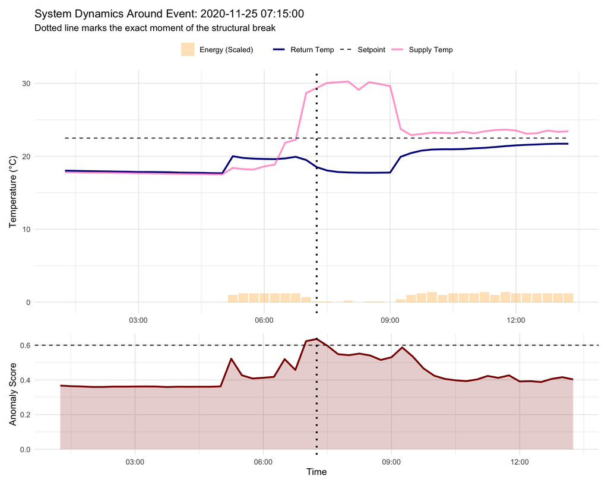

Dynamic Cross-Section: The Sudden Trip Fault Signature

```r
library(ggplot2)
library(dplyr)
library(lubridate)
# install.packages("patchwork") # Run in console if needed
library(patchwork)

# 1. Identify a classic "Sudden Trip" event (Signature 2 from our extreme pool)
# We filter for a sharp negative energy surge and grab the most extreme score
target_event <- hvac_scored %>%
  filter(anomaly_score > 0.6, energy_deriv_15m < -5) %>%
  arrange(desc(anomaly_score)) %>%
  slice(1) %>%
  pull(timestamp)

# 2. Extract a 12-hour window (+/- 6 hours) around the event
blast_radius <- hvac_scored %>%
  filter(
    timestamp >= (target_event - hours(6)),
    timestamp <= (target_event + hours(6))
  )

# 3. Plot the raw physics (Energy and Temperature)
p_physics <- ggplot(blast_radius, aes(x = timestamp)) +
  geom_line(aes(y = t_return, color = "Return Temp"), linewidth = 1) +
  geom_line(aes(y = t_supply, color = "Supply Temp"), linewidth = 1, alpha = 0.6) +
  geom_step(aes(y = sp_return, color = "Setpoint"), linetype = "dashed") +
  # Adding energy on a secondary visual scale (scaled for visibility against temp)
  geom_col(aes(y = energy / 10, fill = "Energy (Scaled)"), alpha = 0.3) +
  geom_vline(xintercept = target_event, color = "black", linetype = "dotted", linewidth = 1) +
  scale_color_manual(values = c("Return Temp" = "darkblue", "Supply Temp" = "hotpink", "Setpoint" = "black")) +
  scale_fill_manual(values = c("Energy (Scaled)" = "orange")) +
  theme_minimal() +
  labs(
    title = sprintf("System Dynamics Around Event: %s", target_event),
    subtitle = "Dotted line marks the exact moment of the structural break",
    x = NULL, y = "Temperature (°C)"
  ) +
  theme(legend.position = "top", legend.title = element_blank())

# 4. Plot the Anomaly Score profile
p_score <- ggplot(blast_radius, aes(x = timestamp, y = anomaly_score)) +
  geom_area(fill = "darkred", alpha = 0.2) +
  geom_line(color = "darkred", linewidth = 1) +
  geom_hline(yintercept = 0.6, linetype = "dashed", color = "black") +
  geom_vline(xintercept = target_event, color = "black", linetype = "dotted", linewidth = 1) +
  theme_minimal() +
  labs(
    x = "Time", y = "Anomaly Score"
  )

# 5. Stack the plots using patchwork
p_physics / p_score + plot_layout(heights = c(2, 1))
```

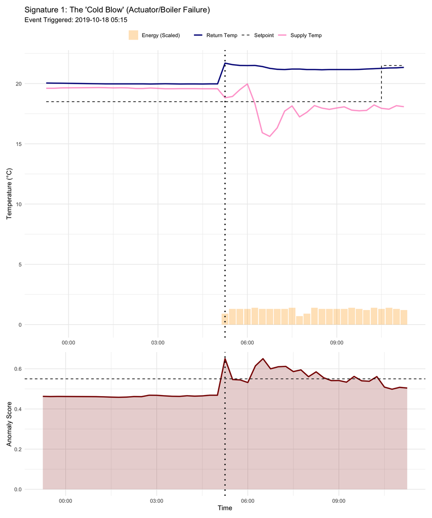

Dynamic Cross-Sections: Cold Blow and Envelope Breach

```r
# 1. Permanently assign the k=3 clusters to the expanded dataset
expanded_anomalies <- expanded_anomalies %>%
  mutate(cluster = as.factor(cutree(as.hclust(diana_exp), k = 3)))

# 2. Extract the single most extreme event for Signature 1 (Cold Blow)
event_sig1 <- expanded_anomalies %>%
  filter(cluster == 1) %>%
  arrange(desc(anomaly_score)) %>%
  slice(1) %>%
  pull(timestamp)

# 3. Extract the single most extreme event for Signature 3 (Envelope Breach)
event_sig3 <- expanded_anomalies %>%
  filter(cluster == 3) %>%
  arrange(desc(anomaly_score)) %>%
  slice(1) %>%
  pull(timestamp)

# 4. Create a reusable function to plot the 12-hour blast radius
plot_blast_radius <- function(target_time, title_text) {

  window_data <- hvac_scored %>%
    filter(
      timestamp >= (target_time - hours(6)),
      timestamp <= (target_time + hours(6))
    )

  p_phys <- ggplot(window_data, aes(x = timestamp)) +
    geom_line(aes(y = t_return, color = "Return Temp"), linewidth = 1) +
    geom_line(aes(y = t_supply, color = "Supply Temp"), linewidth = 1, alpha = 0.6) +
    geom_step(aes(y = sp_return, color = "Setpoint"), linetype = "dashed") +
    geom_col(aes(y = energy / 10, fill = "Energy (Scaled)"), alpha = 0.3) +
    geom_vline(xintercept = target_time, color = "black", linetype = "dotted", linewidth = 1) +
    scale_color_manual(values = c("Return Temp" = "darkblue", "Supply Temp" = "hotpink", "Setpoint" = "black")) +
    scale_fill_manual(values = c("Energy (Scaled)" = "orange")) +
    theme_minimal() +
    labs(
      title = title_text,
      subtitle = sprintf("Event Triggered: %s", format(target_time, "%Y-%m-%d %H:%M")),
      x = NULL, y = "Temperature (°C)"
    ) +
    theme(legend.position = "top", legend.title = element_blank())

  p_score <- ggplot(window_data, aes(x = timestamp, y = anomaly_score)) +
    geom_area(fill = "darkred", alpha = 0.2) +
    geom_line(color = "darkred", linewidth = 1) +
    geom_hline(yintercept = 0.55, linetype = "dashed", color = "black") +
    geom_vline(xintercept = target_time, color = "black", linetype = "dotted", linewidth = 1) +
    theme_minimal() +
    labs(x = "Time", y = "Anomaly Score")

  return(p_phys / p_score + plot_layout(heights = c(2, 1)))
}

# 5. Generate and display the two diagnostic plots
plot_sig1 <- plot_blast_radius(event_sig1, "Signature 1: The 'Cold Blow' (Actuator/Boiler Failure)")
plot_sig3 <- plot_blast_radius(event_sig3, "Signature 3: The 'Envelope Breach' (Thermal Boundary Loss)")

# Display plots side-by-side or stacked in the report
plot_sig1
```

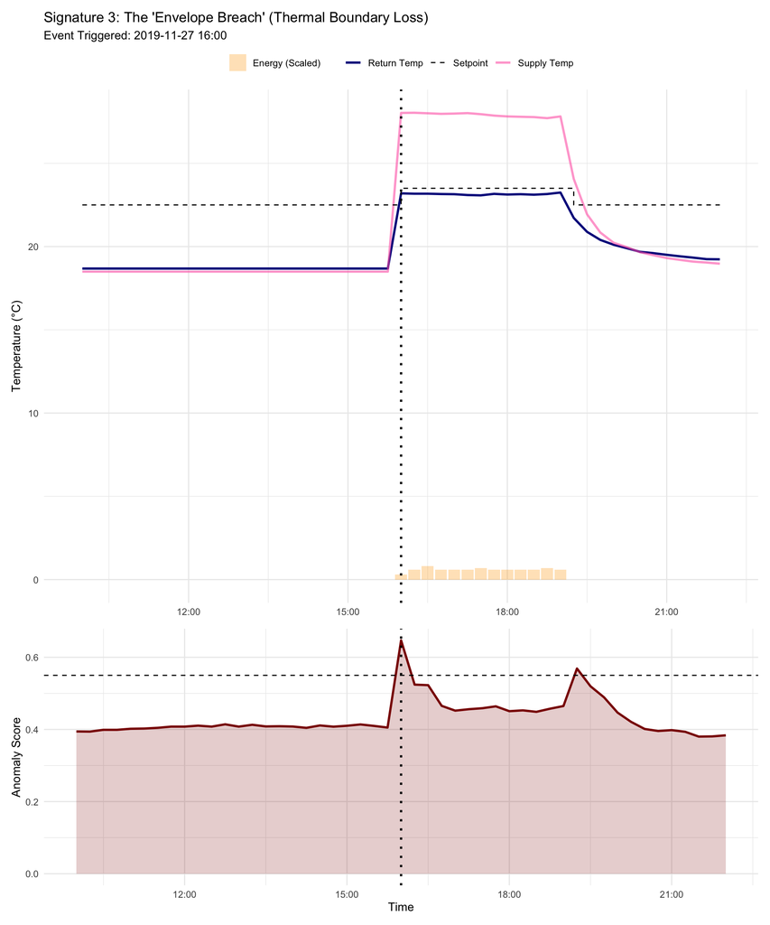

Dynamic Cross-Sections: Cold Blow and Envelope Breach

```r
plot_sig3
```

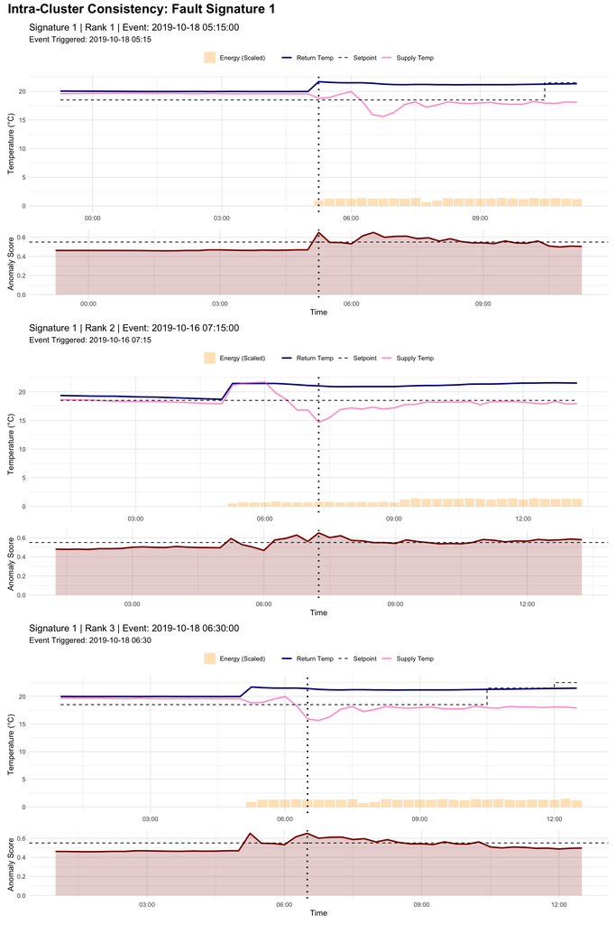

```r
library(purrr)
library(patchwork)

# 1. Function to extract and plot the Top N events for a specific cluster
plot_cluster_top_n <- function(cluster_id, n = 3) {

  # Extract the top N timestamps for this specific cluster
  top_events <- expanded_anomalies %>%
    filter(cluster == cluster_id) %>%
    arrange(desc(anomaly_score)) %>%
    slice(1:n) %>%
    pull(timestamp)

  # Map the timestamps to our previously built plot_blast_radius function
  plots <- map2(
    top_events,
    seq_along(top_events),
    ~plot_blast_radius(.x, sprintf("Signature %d | Rank %d | Event: %s", cluster_id, .y, .x))
  )

  # Wrap the plots vertically into a single cohesive column
  combined_plot <- wrap_plots(plots, ncol = 1) +
    plot_annotation(
      title = sprintf("Intra-Cluster Consistency: Fault Signature %d", cluster_id),
      theme = theme(plot.title = element_text(size = 18, face = "bold"))
    )

  return(combined_plot)
}

# 2. Generate the visual sheets for all three clusters
consistency_sig1 <- plot_cluster_top_n(cluster_id = 1, n = 3)
consistency_sig2 <- plot_cluster_top_n(cluster_id = 2, n = 3)
consistency_sig3 <- plot_cluster_top_n(cluster_id = 3, n = 3)

# 3. Print them to the Quarto document
consistency_sig1
```

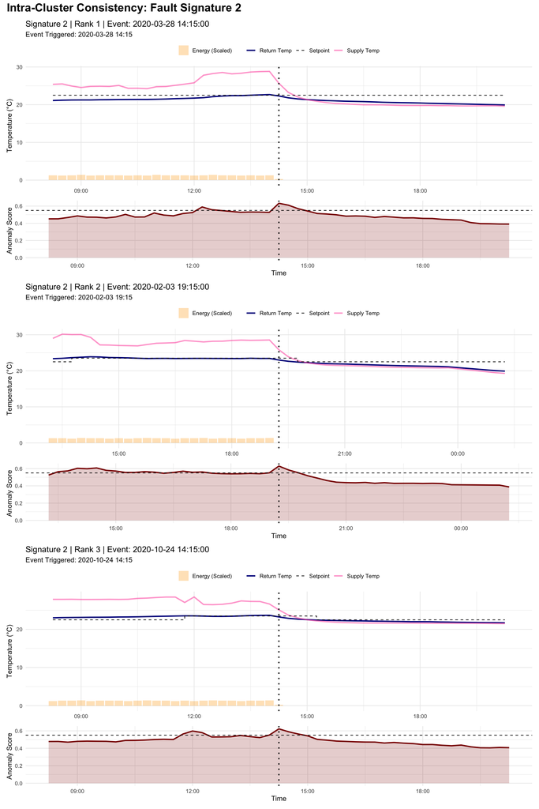

```r
consistency_sig2
```

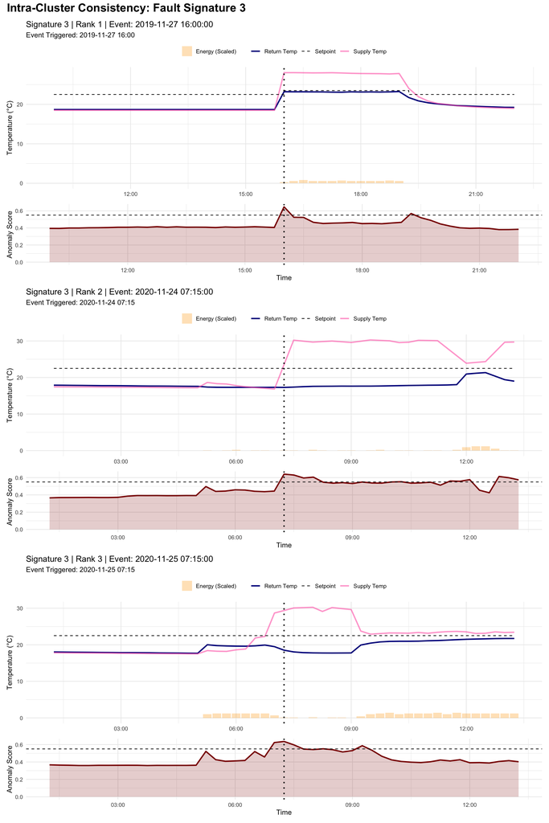

```r
consistency_sig3
```

```r
library(dplyr)
library(lubridate)

# 1. Sort and calculate temporal gaps within each physical cluster
temporal_events <- expanded_anomalies %>%
  arrange(cluster, timestamp) %>%
  group_by(cluster) %>%
  mutate(
    # Calculate time since previous anomaly in the SAME cluster
    time_gap = as.numeric(difftime(timestamp, lag(timestamp, default = first(timestamp)), units = "hours")),

    # If the gap is greater than 6 hours, flag it as a new discrete event
    is_new_event = ifelse(time_gap > 6, 1, 0),

    # Cumulative sum generates a unique ID for each continuous temporal block
    sub_event_id = cumsum(is_new_event) + 1
  ) %>%
  ungroup() %>%
  # Create a global unique Event ID combining physics and time
  mutate(event_id = paste0("Sig", cluster, "_Evt", sub_event_id))

# 2. Aggregate the individual timestamps into discrete Event Profiles
event_summary <- temporal_events %>%
  group_by(cluster, event_id) %>%
  summarize(
    onset_time = min(timestamp),
    resolution_time = max(timestamp),
    # Calculate how long the machine remained in a state of failure
    duration_hrs = as.numeric(difftime(resolution_time, onset_time, units = "hours")),
    peak_severity = max(anomaly_score),
    affected_intervals = n(),
    .groups = 'drop'
  ) %>%
  arrange(desc(peak_severity))

# 3. Output the compression results
cat(sprintf("Compressed %d individual anomalies into %d discrete physical events.\n\n",
            nrow(expanded_anomalies), nrow(event_summary)))
```

```
Compressed 425 individual anomalies into 256 discrete physical events.
```

```r
# Display the top 10 most severe discrete events
knitr::kable(head(event_summary, 15))
```

| cluster | event_id | onset_time | resolution_time | duration_hrs | peak_severity | affected_intervals |
| --- | --- | --- | --- | --- | --- | --- |
| 1 | Sig1_Evt3 | 2019-10-18 05:15:00 | 2019-10-18 10:15:00 | 5.00 | 0.6507732 | 13 |
| 1 | Sig1_Evt1 | 2019-10-16 05:15:00 | 2019-10-16 14:45:00 | 9.50 | 0.6505006 | 28 |
| 3 | Sig3_Evt10 | 2019-11-27 16:00:00 | 2019-11-27 16:00:00 | 0.00 | 0.6469691 | 1 |
| 1 | Sig1_Evt42 | 2021-03-06 05:15:00 | 2021-03-06 09:30:00 | 4.25 | 0.6416874 | 7 |
| 3 | Sig3_Evt56 | 2020-11-24 07:15:00 | 2020-11-24 13:15:00 | 6.00 | 0.6407392 | 11 |
| 3 | Sig3_Evt57 | 2020-11-25 07:00:00 | 2020-11-25 08:15:00 | 1.25 | 0.6357646 | 4 |
| 2 | Sig2_Evt75 | 2020-03-28 12:30:00 | 2020-03-28 14:45:00 | 2.25 | 0.6331390 | 4 |
| 1 | Sig1_Evt38 | 2021-03-02 05:15:00 | 2021-03-02 05:30:00 | 0.25 | 0.6315906 | 2 |
| 2 | Sig2_Evt49 | 2020-02-03 13:30:00 | 2020-02-03 19:45:00 | 6.25 | 0.6290642 | 19 |
| 3 | Sig3_Evt55 | 2020-11-23 08:15:00 | 2020-11-23 11:00:00 | 2.75 | 0.6273614 | 7 |
| 1 | Sig1_Evt37 | 2021-03-01 03:15:00 | 2021-03-01 06:30:00 | 3.25 | 0.6255614 | 5 |
| 1 | Sig1_Evt2 | 2019-10-17 05:15:00 | 2019-10-17 07:45:00 | 2.50 | 0.6238634 | 7 |
| 2 | Sig2_Evt89 | 2020-10-24 11:45:00 | 2020-10-24 14:45:00 | 3.00 | 0.6227569 | 7 |
| 2 | Sig2_Evt74 | 2020-03-21 12:15:00 | 2020-03-21 14:30:00 | 2.25 | 0.6206802 | 3 |
| 2 | Sig2_Evt77 | 2020-04-04 12:00:00 | 2020-04-04 14:45:00 | 2.75 | 0.6183866 | 6 |

AUC score

[output not shown]

[output cut: 30 more lines]

```r
# Define the baseline threshold used for event generation
baseline_threshold <- 0.55

# 1. Re-aggregate with the Excess AUC metric
operational_event_summary <- temporal_events %>%
  group_by(cluster, event_id) %>%
  summarize(
    onset_time = min(timestamp),
    resolution_time = max(timestamp),
    duration_hrs = as.numeric(difftime(resolution_time, onset_time, units = "hours")),
    peak_severity = max(anomaly_score),
    affected_intervals = n(),

    # Mathematical Fix: Sum only the area above the threshold
    excess_auc = round(sum(anomaly_score - baseline_threshold), 3),
    .groups = 'drop'
  ) %>%
  mutate(
    triage_level = factor(case_when(
      duration_hrs >= 2.0 ~ "Priority 1 (Dispatch)",
      duration_hrs >= 0.5 & duration_hrs < 2.0 ~ "Priority 2 (Queue)",
      duration_hrs < 0.5 ~ "Priority 3 (Forensic/Watchlist)"
    ), levels = c("Priority 1 (Dispatch)", "Priority 2 (Queue)", "Priority 3 (Forensic/Watchlist)"))
  ) %>%
  # Sort by Cluster first, then by the new Excess AUC within that cluster
  arrange(cluster, desc(excess_auc))

# 2. Route the output into specialized dispatch queues
dispatch_queues <- split(operational_event_summary, operational_event_summary$cluster)

# 3. Print the top priority tickets for the Mechanical (Sig 1) and Electrical (Sig 2) queues
cat("--- MECHANICAL DISPATCH QUEUE (Signature 1: Cold Blow / Actuator) ---\n")
```

```
--- MECHANICAL DISPATCH QUEUE (Signature 1: Cold Blow / Actuator) ---
```

```r
print(head(dispatch_queues[["1"]], 3), width = Inf)
```

```
# A tibble: 3 × 9
  cluster event_id  onset_time          resolution_time     duration_hrs
  <fct>   <chr>     <dttm>              <dttm>                     <dbl>
1 1       Sig1_Evt1 2019-10-16 05:15:00 2019-10-16 14:45:00          9.5
2 1       Sig1_Evt3 2019-10-18 05:15:00 2019-10-18 10:15:00          5
3 1       Sig1_Evt2 2019-10-17 05:15:00 2019-10-17 07:45:00          2.5
  peak_severity affected_intervals excess_auc triage_level
          <dbl>              <int>      <dbl> <fct>
1         0.651                 28      0.887 Priority 1 (Dispatch)
2         0.651                 13      0.591 Priority 1 (Dispatch)
3         0.624                  7      0.283 Priority 1 (Dispatch)
```

```r
cat("\n--- ELECTRICAL DISPATCH QUEUE (Signature 2: Sudden Trip) ---\n")
```

```
--- ELECTRICAL DISPATCH QUEUE (Signature 2: Sudden Trip) ---
```

```r
print(head(dispatch_queues[["2"]], 3), width = Inf)
```

```
# A tibble: 3 × 9
  cluster event_id   onset_time          resolution_time     duration_hrs
  <fct>   <chr>      <dttm>              <dttm>                     <dbl>
1 2       Sig2_Evt49 2020-02-03 13:30:00 2020-02-03 19:45:00         6.25
2 2       Sig2_Evt89 2020-10-24 11:45:00 2020-10-24 14:45:00         3
3 2       Sig2_Evt75 2020-03-28 12:30:00 2020-03-28 14:45:00         2.25
  peak_severity affected_intervals excess_auc triage_level
          <dbl>              <int>      <dbl> <fct>
1         0.629                 19      0.441 Priority 1 (Dispatch)
2         0.623                  7      0.219 Priority 1 (Dispatch)
3         0.633                  4      0.173 Priority 1 (Dispatch)
```

```r
cat("\n--- ELECTRICAL DISPATCH QUEUE (Signature 3: Envelope Breach/Sensor Illusion) ---\n")
```

```
--- ELECTRICAL DISPATCH QUEUE (Signature 3: Envelope Breach/Sensor Illusion) ---
```

```r
print(head(dispatch_queues[["3"]], 3), width = Inf)
```

```
# A tibble: 3 × 9
  cluster event_id   onset_time          resolution_time     duration_hrs
  <fct>   <chr>      <dttm>              <dttm>                     <dbl>
1 3       Sig3_Evt56 2020-11-24 07:15:00 2020-11-24 13:15:00         6
2 3       Sig3_Evt58 2020-11-26 07:15:00 2020-11-26 12:45:00         5.5
3 3       Sig3_Evt57 2020-11-25 07:00:00 2020-11-25 08:15:00         1.25
  peak_severity affected_intervals excess_auc triage_level
          <dbl>              <int>      <dbl> <fct>
1         0.641                 11      0.433 Priority 1 (Dispatch)
2         0.603                 13      0.211 Priority 1 (Dispatch)
3         0.636                  4      0.207 Priority 2 (Queue)
```

Fault Signatures & Dispatch Routing Signature 1: The ‘Cold Blow’ (Mechanical/Thermodynamic)

Symptom: The system draws heavy energy and attempts to heat/cool, but no thermal exchange occurs (e.g., supply temperature flatlines).

Required Personnel: Mechanical HVAC Technician (to inspect stuck actuators, broken boiler valves, or blocked ducts).

Signature 2: The ‘Sudden Trip’ (Electrical/Kinematic)

Symptom: An instantaneous drop in energy consumption to zero despite a high setpoint demand, resulting in stagnant supply air.

Required Personnel: Licensed Electrician or Building Engineer (to reset tripped breakers, inspect motor relays, or diagnose power loss).

Signature 3: The ‘Telemetry Illusion’ / ‘Envelope Breach’ (Digital/Structural)

Symptom: Physically impossible thermodynamics (e.g., room temperature jumping 5°C in 15 minutes with zero energy draw) or a total loss of the thermal boundary.

Required Personnel: IT/Controls Technician (to recalibrate or replace short-circuited sensors) or Facility Management (to secure open doors/windows).

```r
# install.packages("dtw") # Run in console if needed
library(dtw)
library(purrr)
library(tidyr)
library(dplyr)
library(lubridate)
library(cluster)

# 1. Isolate the 52 extreme events and their assigned k=3 clusters
extreme_events <- hvac_scored %>%
  filter(anomaly_score > 0.6) %>%
  # Re-run the strict k=3 clustering for just these 52 to ensure alignment
  mutate(cluster = as.factor(cutree(as.hclust(diana(scale(
    dplyr::select(., temp_error, delta_t, energy_deriv_15m, delta_t_deriv_15m)
  ))), k = 3))) %>%
  dplyr::select(timestamp, cluster)

# 2. Extract a standardized 4-hour MULTIVARIATE time-series matrix for each event
extract_ts_window_multi <- function(target_time) {
  hvac_scored %>%
    filter(
      timestamp >= (target_time - hours(2)),
      timestamp <= (target_time + hours(2))
    ) %>%
    # Select the exact same physics used in the DIANA clustering
    dplyr::select(temp_error, delta_t, energy_deriv_15m, delta_t_deriv_15m) %>%
    # Z-score normalize the entire matrix so energy and temp are on the same scale
    scale() %>%
    as.matrix()
}

# Apply multivariate extraction to all 52 events
event_ts_list_multi <- map(extreme_events$timestamp, extract_ts_window_multi)
names(event_ts_list_multi) <- paste0("Event_", 1:nrow(extreme_events))

# 3. Compute the O(N^2) MDTW distance matrix
mdtw_dist_matrix <- matrix(NA, nrow = 52, ncol = 52)

for (i in 1:52) {
  for (j in 1:52) {
    # The dtw() function automatically handles matrix vs matrix comparisons
    mdtw_dist_matrix[i, j] <- dtw(event_ts_list_multi[[i]],
                                  event_ts_list_multi[[j]],
                                  distance.only = TRUE)$normalizedDistance
  }
}

# 4. Summarize the Intra-Cluster vs Inter-Cluster distances
dtw_results <- expand_grid(
  Event_A = 1:52,
  Event_B = 1:52
) %>%
  mutate(
    Cluster_A = extreme_events$cluster[Event_A],
    Cluster_B = extreme_events$cluster[Event_B],
    Distance = as.vector(mdtw_dist_matrix) # FIXED: Now calling the MDTW matrix
  ) %>%
  filter(Event_A != Event_B) %>% # Remove self-comparisons (distance = 0)
  mutate(Comparison_Type = ifelse(Cluster_A == Cluster_B,
                                  "Intra-Cluster (Same Fault)",
                                  "Inter-Cluster (Different Faults)"))

# 5. Print the mathematical proof
dtw_summary <- dtw_results %>%
  group_by(Comparison_Type) %>%
  summarize(
    Mean_Warping_Distance = round(mean(Distance), 2),
    Median_Warping_Distance = round(median(Distance), 2)
  )

print(dtw_summary)
```

```
# A tibble: 2 × 3
  Comparison_Type                  Mean_Warping_Distance Median_Warping_Distance
  <chr>                                            <dbl>                   <dbl>
1 Inter-Cluster (Different Faults)                  1.8                     1.88
2 Intra-Cluster (Same Fault)                        1.33                    1.38
```

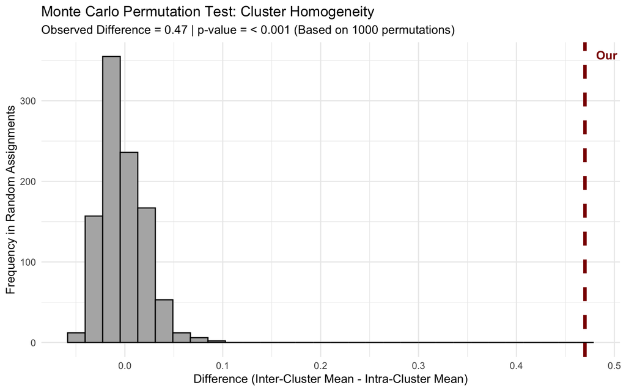

```r
library(ggplot2)

# 1. Define our observed test statistic (Inter - Intra mean from your tibble)
observed_diff <- 1.80 - 1.33

# 2. Extract the actual distance matrix and true cluster labels
# We use the mdtw_dist_matrix generated in the previous chunk
true_labels <- extreme_events$cluster

# 3. Setup the Monte Carlo permutation test
n_permutations <- 1000
null_distribution <- numeric(n_permutations)

# Set seed for reproducible forensics
set.seed(42)

for(i in 1:n_permutations) {
  # Shuffle the cluster assignments randomly
  shuffled_labels <- sample(true_labels)

  # Create a logical matrix to identify which pairs are now "Intra-cluster"
  is_intra <- outer(shuffled_labels, shuffled_labels, "==")

  # Use the upper triangle to avoid double counting and self-comparisons
  upper_tri <- upper.tri(mdtw_dist_matrix)

  # Extract the randomized distances
  sim_intra_dists <- mdtw_dist_matrix[upper_tri & is_intra]
  sim_inter_dists <- mdtw_dist_matrix[upper_tri & !is_intra]

  # Calculate the simulated test statistic for this permutation
  null_distribution[i] <- mean(sim_inter_dists, na.rm = TRUE) - mean(sim_intra_dists, na.rm = TRUE)
}

# 4. Calculate the empirical p-value
p_value <- sum(null_distribution >= observed_diff) / n_permutations

# 5. Visualize the proof
mc_results <- data.frame(Simulated_Diff = null_distribution)

ggplot(mc_results, aes(x = Simulated_Diff)) +
  geom_histogram(fill = "gray70", color = "black", bins = 30) +
  geom_vline(xintercept = observed_diff, color = "darkred", linewidth = 1.5, linetype = "dashed") +
  theme_minimal() +
  labs(
    title = "Monte Carlo Permutation Test: Cluster Homogeneity",
    subtitle = sprintf("Observed Difference = %s | p-value = %s (Based on %d permutations)",
                       observed_diff, format.pval(p_value, eps = 0.001), n_permutations),
    x = "Difference (Inter-Cluster Mean - Intra-Cluster Mean)",
    y = "Frequency in Random Assignments"
  ) +
  annotate("text", x = observed_diff, y = Inf, label = "Our Model's Reality",
           color = "darkred", vjust = 2, hjust = -0.1, fontface = "bold")
```

Here is the exact formula we are coding for the multivariate $T$ statistic between any two clusters $C_k$ and $C_l$:
$$T_{kl} = \frac{m(C_k, C_l)}{s(C_k) + s(C_l)}$$
Where: - $m(C_k, C_l)$: The average pairwise distance between elements of different clusters. - $s(C_k)$: The average pairwise distance within a single cluster.

```r
library(dplyr)
library(tidyr)

# 1. Define the mathematical helper functions for the Sobolev T-statistic
calc_s <- function(dist_mat, indices) {
  # Average intra-cluster distance
  n <- length(indices)
  if (n < 2) return(NA) # Cannot compute for single-element clusters
  sub_mat <- dist_mat[indices, indices]
  # Sum only the upper triangle to avoid double counting, then apply formula
  return(sum(sub_mat[upper.tri(sub_mat)]) * 2 / (n * (n - 1)))
}

calc_m <- function(dist_mat, indices_k, indices_l) {
  # Average inter-cluster distance
  nk <- length(indices_k)
  nl <- length(indices_l)
  if (nk == 0 | nl == 0) return(NA)
  sub_mat <- dist_mat[indices_k, indices_l]
  return(sum(sub_mat) / (nk * nl))
}

calc_T_matrix <- function(dist_mat, labels) {
  # Generate the full pairwise T-statistic matrix for k clusters
  unique_clusters <- sort(unique(labels))
  k <- length(unique_clusters)
  T_mat <- matrix(NA, nrow = k, ncol = k,
                  dimnames = list(unique_clusters, unique_clusters))

  # Precompute s(C) for all clusters to save redundant operations
  s_vals <- sapply(unique_clusters, function(c) {
    calc_s(dist_mat, which(labels == c))
  })

  # Calculate T_kl for the upper triangle
  for (i in 1:(k-1)) {
    for (j in (i+1):k) {
      idx_k <- which(labels == unique_clusters[i])
      idx_l <- which(labels == unique_clusters[j])

      m_val <- calc_m(dist_mat, idx_k, idx_l)
      T_mat[i, j] <- m_val / (s_vals[i] + s_vals[j])
    }
  }
  return(T_mat)
}

# 2. Calculate the True Observed T-Matrix
true_labels <- extreme_events$cluster
observed_T_mat <- calc_T_matrix(mdtw_dist_matrix, true_labels)

# 3. Execute the Size-Preserved Monte Carlo Permutations
n_permutations <- 1000
set.seed(42)

# Initialize an array to hold all 1000 simulated 3x3 matrices
sim_T_arrays <- array(NA, dim = c(3, 3, n_permutations))

for (p in 1:n_permutations) {
  # Shuffling the labels vector guarantees identical group sizes |Ck| and |Cl|
  shuffled_labels <- sample(true_labels)
  sim_T_arrays[, , p] <- calc_T_matrix(mdtw_dist_matrix, shuffled_labels)
}

# 4. Calculate the empirical p-value element-by-element
p_value_mat <- matrix(NA, nrow = 3, ncol = 3,
                      dimnames = dimnames(observed_T_mat))

for (i in 1:2) {
  for (j in (i+1):3) {
    obs_val <- observed_T_mat[i, j]
    # Extract the vector of 1000 simulated values for this specific T_kl pair
    sim_vals <- sim_T_arrays[i, j, ]

    # Calculate how often a random distribution generated a T-stat >= our observed
    p_value_mat[i, j] <- sum(sim_vals >= obs_val, na.rm = TRUE) / n_permutations
  }
}

# 5. Format and print the final proof
results_df <- data.frame(
  Pair = c("Sig 1 vs Sig 2", "Sig 1 vs Sig 3", "Sig 2 vs Sig 3"),
  Observed_T = c(observed_T_mat[1,2], observed_T_mat[1,3], observed_T_mat[2,3]),
  p_value = c(p_value_mat[1,2], p_value_mat[1,3], p_value_mat[2,3])
) %>%
  mutate(
    Observed_T = round(Observed_T, 3),
    Significance = ifelse(p_value < 0.001, "< 0.001", as.character(p_value))
  )

cat("--- Sobolev Multivariate T-Statistic Matrix Proof ---\n\n")
```

```
--- Sobolev Multivariate T-Statistic Matrix Proof ---
```

```r
print(results_df, row.names = FALSE)
```

```
           Pair Observed_T p_value Significance
 Sig 1 vs Sig 2      0.608       0      < 0.001
 Sig 1 vs Sig 3      0.673       0      < 0.001
 Sig 2 vs Sig 3      0.757       0      < 0.001
```

```r
# 1. Force DIANA to split the data into 4 clusters instead of 3
extreme_events_k4 <- hvac_scored %>%
  filter(anomaly_score > 0.6) %>%
  mutate(cluster = as.factor(cutree(as.hclust(diana(scale(
    dplyr::select(., temp_error, delta_t, energy_deriv_15m, delta_t_deriv_15m)
  ))), k = 4)))

true_labels_k4 <- extreme_events_k4$cluster

# 2. Calculate the True Observed T-Matrix for the 4 clusters
observed_T_mat_k4 <- calc_T_matrix(mdtw_dist_matrix, true_labels_k4)

# 3. Execute the Size-Preserved Monte Carlo Permutations
n_permutations <- 10000
set.seed(42)

sim_T_arrays_k4 <- array(NA, dim = c(4, 4, n_permutations))

for (p in 1:n_permutations) {
  shuffled_labels_k4 <- sample(true_labels_k4)
  sim_T_arrays_k4[, , p] <- calc_T_matrix(mdtw_dist_matrix, shuffled_labels_k4)
}

# 4. Calculate the empirical p-value for all 6 possible pairs
pairs_list <- list()
row_idx <- 1

for (i in 1:3) {
  for (j in (i+1):4) {
    obs_val <- observed_T_mat_k4[i, j]
    sim_vals <- sim_T_arrays_k4[i, j, ]
    p_val <- sum(sim_vals >= obs_val, na.rm = TRUE) / n_permutations

    pairs_list[[ row_idx]] <- data.frame(
      Pair = paste("Sig", i, "vs Sig", j),
      Observed_T = obs_val,
      p_value = p_val
    )
    row_idx <- row_idx + 1
  }
}

# 5. Format and print the final proof
results_k4 <- bind_rows(pairs_list) %>%
  mutate(
    Observed_T = round(Observed_T, 4),
    Significance = ifelse(p_value < 0.0001, "< 0.0001", as.character(signif(p_value, 3)))
  ) %>%
  arrange(desc(p_value), Observed_T) # Sort so the worst pair bubbles to the top

cat("--- Sobolev T-Statistic Proof (Forced k=4 Split) ---\n\n")
```

```
--- Sobolev T-Statistic Proof (Forced k=4 Split) ---
```

```r
print(results_k4, row.names = FALSE)
```

```
           Pair Observed_T p_value Significance
 Sig 3 vs Sig 4     0.6773   7e-04        7e-04
 Sig 1 vs Sig 2     0.6082   0e+00     < 0.0001
 Sig 1 vs Sig 4     0.6733   0e+00     < 0.0001
 Sig 2 vs Sig 4     0.7531   0e+00     < 0.0001
 Sig 1 vs Sig 3     0.8368   0e+00     < 0.0001
 Sig 2 vs Sig 3     0.9712   0e+00     < 0.0001
```

```r
# 1. Add original row indices to keep track of the matrix positions
extreme_events <- extreme_events %>%
  mutate(matrix_idx = row_number())

# 2. Function to find the Medoid for a given cluster
get_cluster_medoid <- function(target_cluster) {
  # Get the matrix indices for the events in this cluster
  cluster_indices <- extreme_events %>%
    filter(cluster == target_cluster) %>%
    pull(matrix_idx)

  # Subset the MDTW distance matrix for just these events
  sub_matrix <- mdtw_dist_matrix[cluster_indices, cluster_indices]

  # Find the local index with the minimum sum of distances to all others
  medoid_local_idx <- which.min(rowSums(sub_matrix))

  # Map back to the global event ID and timestamp
  medoid_global_idx <- cluster_indices[medoid_local_idx]
  medoid_timestamp <- extreme_events$timestamp[medoid_global_idx]

  return(medoid_timestamp)
}

# 3. Extract the exact timestamps for the three Archetypes
archetype_sig1 <- get_cluster_medoid(1)
archetype_sig2 <- get_cluster_medoid(2)
archetype_sig3 <- get_cluster_medoid(3)

cat(sprintf("Archetype for Signature 1 (Cold Blow): %s\n", archetype_sig1))
```

```
Archetype for Signature 1 (Cold Blow): 2019-10-18 06:30:00
```

```r
cat(sprintf("Archetype for Signature 2 (Sudden Trip): %s\n", archetype_sig2))
```

```
Archetype for Signature 2 (Sudden Trip): 2020-03-28 14:30:00
```

```r
cat(sprintf("Archetype for Signature 3 (Envelope/Digital): %s\n\n", archetype_sig3))
```

```
Archetype for Signature 3 (Envelope/Digital): 2020-11-24 07:15:00
```

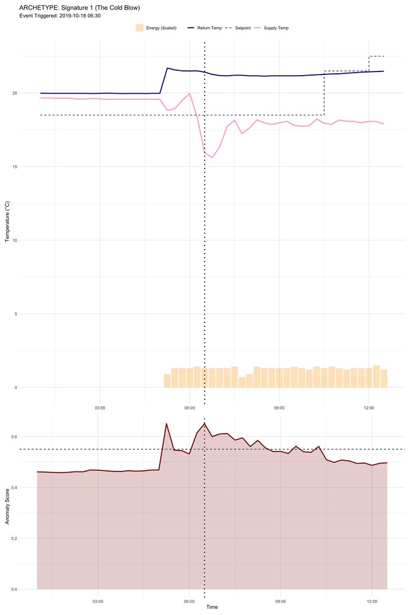

```r
# 4. Visualize the Archetypes individually
plot_a1 <- plot_blast_radius(archetype_sig1, "ARCHETYPE: Signature 1 (The Cold Blow)")
plot_a2 <- plot_blast_radius(archetype_sig2, "ARCHETYPE: Signature 2 (The Sudden Trip)")
plot_a3 <- plot_blast_radius(archetype_sig3, "ARCHETYPE: Signature 3 (The Envelope Breach)")

# Print sequentially instead of wrapping into a single mega-plot
plot_a1
```

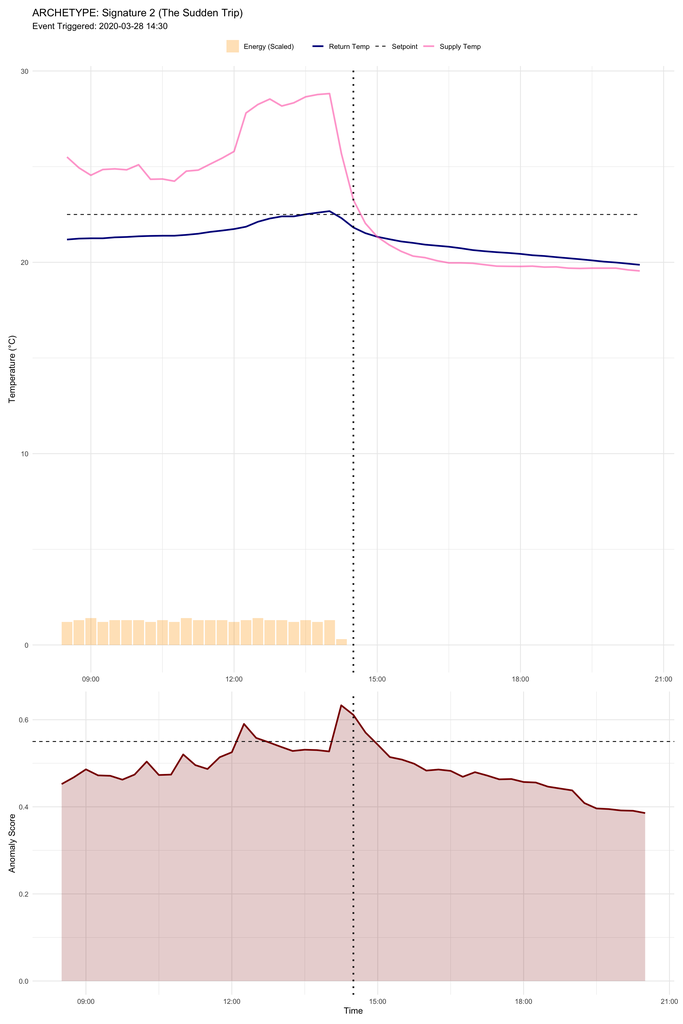

```r
plot_a2
```

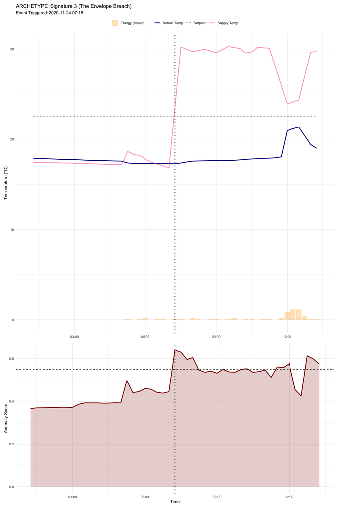

```r
plot_a3
```

```r
library(cluster)
library(dplyr)
library(tidyr)
library(ggplot2)

# 1. Re-establish the baseline DIANA clustering tree
event_features <- hvac_scored %>%
  filter(anomaly_score > 0.6) %>%
  dplyr::select(temp_error, delta_t, energy_deriv_15m, delta_t_deriv_15m) %>%
  scale()

# Compute the hierarchical tree once
hc_tree <- as.hclust(diana(event_features))

# 2. Define the Harmonic Pairwise Silhouette function
calc_harmonic_pairwise_sil <- function(dist_mat, labels) {
  k_unique <- sort(unique(labels))
  k <- length(k_unique)

  pairwise_means <- c()

  for (i in 1:(k-1)) {
    for (j in (i+1):k) {
      cl_A <- k_unique[i]
      cl_B <- k_unique[j]

      idx <- which(labels %in% c(cl_A, cl_B))
      sub_mat <- dist_mat[idx, idx]
      sub_labels <- as.character(labels[idx])

      # Calculate silhouette for this specific pair
      sil_obj <- silhouette(as.numeric(as.factor(sub_labels)), dmatrix = sub_mat)
      mean_sil <- mean(sil_obj[, "sil_width"])

      # Strict Penalty: Clamp negative/zero scores to 0.001 to penalize the harmonic mean
      if (is.na(mean_sil) || mean_sil <= 0) mean_sil <- 0.001

      pairwise_means <- c(pairwise_means, mean_sil)
    }
  }

  # Harmonic Mean formula: m / sum(1/x)
  h_mean <- length(pairwise_means) / sum(1 / pairwise_means)
  return(h_mean)
}

# 3. Define the Global Silhouette function
calc_global_sil <- function(dist_mat, labels) {
  sil_obj <- silhouette(as.numeric(as.factor(labels)), dmatrix = dist_mat)
  return(mean(sil_obj[, "sil_width"]))
}

# 4. Execute the iteration loop
k_values <- 2:6
results <- data.frame(
  k = k_values,
  Global_Silhouette = NA,
  Harmonic_Pairwise = NA
)

for (i in seq_along(k_values)) {
  current_k <- k_values[i]
  current_labels <- cutree(hc_tree, k = current_k)

  results$Global_Silhouette[i] <- calc_global_sil(mdtw_dist_matrix, current_labels)
  results$Harmonic_Pairwise[i] <- calc_harmonic_pairwise_sil(mdtw_dist_matrix, current_labels)
}

# 5. Print the numerical results
cat("--- Cluster Integrity Analysis (k = 2 to 6) ---\n\n")
```

```
--- Cluster Integrity Analysis (k = 2 to 6) ---
```

```r
print(results %>% mutate(across(where(is.numeric), ~round(., 3))))
```

```
  k Global_Silhouette Harmonic_Pairwise
1 2             0.249             0.249
2 3             0.191             0.236
3 4             0.156             0.255
4 5             0.067             0.034
5 6             0.040             0.011
```

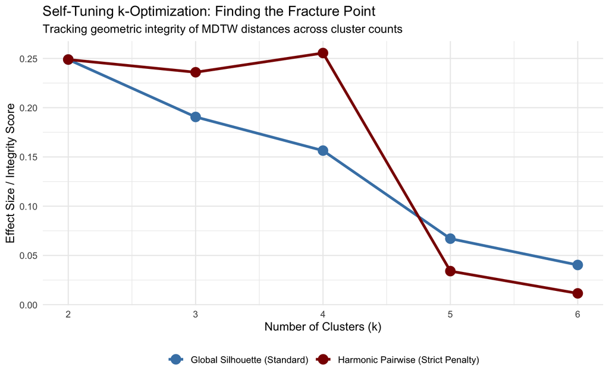

```r
# 6. Plot the Non-Monotonic Curves
results_long <- results %>%
  pivot_longer(cols = c(Global_Silhouette, Harmonic_Pairwise),
               names_to = "Metric", values_to = "Score") %>%
  mutate(Metric = ifelse(Metric == "Global_Silhouette",
                         "Global Silhouette (Standard)",
                         "Harmonic Pairwise (Strict Penalty)"))

ggplot(results_long, aes(x = k, y = Score, color = Metric)) +
  geom_line(linewidth = 1.2) +
  geom_point(size = 4) +
  scale_color_manual(values = c("Global Silhouette (Standard)" = "steelblue",
                                "Harmonic Pairwise (Strict Penalty)" = "darkred")) +
  theme_minimal() +
  labs(
    title = "Self-Tuning k-Optimization: Finding the Fracture Point",
    subtitle = "Tracking geometric integrity of MDTW distances across cluster counts",
    x = "Number of Clusters (k)",
    y = "Effect Size / Integrity Score"
  ) +
  theme(legend.position = "bottom", legend.title = element_blank())
```

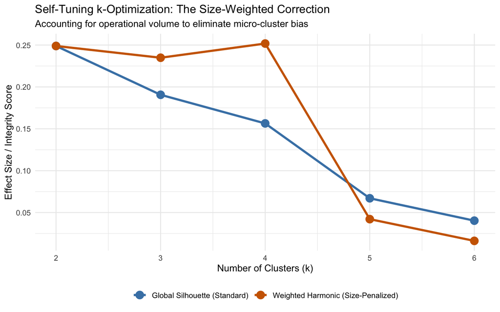

```r
# 1. Define the Weighted Harmonic Pairwise Silhouette function
calc_weighted_harmonic_sil <- function(dist_mat, labels) {
  k_unique <- sort(unique(labels))
  k <- length(k_unique)

  pairwise_scores <- c()
  pairwise_weights <- c()

  for (i in 1:(k-1)) {
    for (j in (i+1):k) {
      cl_A <- k_unique[i]
      cl_B <- k_unique[j]

      idx <- which(labels %in% c(cl_A, cl_B))
      sub_mat <- dist_mat[idx, idx]
      sub_labels <- as.character(labels[idx])

      # Calculate silhouette
      sil_obj <- silhouette(as.numeric(as.factor(sub_labels)), dmatrix = sub_mat)
      mean_sil <- mean(sil_obj[, "sil_width"])

      if (is.na(mean_sil) || mean_sil <= 0) mean_sil <- 0.001

      pairwise_scores <- c(pairwise_scores, mean_sil)

      # The Fix: Weight by the combined operational volume of the two clusters
      weight <- sum(labels == cl_A) + sum(labels == cl_B)
      pairwise_weights <- c(pairwise_weights, weight)
    }
  }

  # Weighted Harmonic Mean formula
  w_h_mean <- sum(pairwise_weights) / sum(pairwise_weights / pairwise_scores)
  return(w_h_mean)
}

# 2. Execute the iteration loop
results_weighted <- data.frame(
  k = k_values,
  Global_Silhouette = results$Global_Silhouette, # Re-use from previous chunk
  Weighted_Harmonic = NA
)

for (i in seq_along(k_values)) {
  current_labels <- cutree(hc_tree, k = k_values[i])
  results_weighted$Weighted_Harmonic[i] <- calc_weighted_harmonic_sil(mdtw_dist_matrix, current_labels)
}

# 3. Plot the Corrected Curves
results_w_long <- results_weighted %>%
  pivot_longer(cols = c(Global_Silhouette, Weighted_Harmonic),
               names_to = "Metric", values_to = "Score") %>%
  mutate(Metric = ifelse(Metric == "Global_Silhouette",
                         "Global Silhouette (Standard)",
                         "Weighted Harmonic (Size-Penalized)"))

ggplot(results_w_long, aes(x = k, y = Score, color = Metric)) +
  geom_line(linewidth = 1.2) +
  geom_point(size = 4) +
  scale_color_manual(values = c("Global Silhouette (Standard)" = "steelblue",
                                "Weighted Harmonic (Size-Penalized)" = "darkorange3")) +
  theme_minimal() +
  labs(
    title = "Self-Tuning k-Optimization: The Size-Weighted Correction",
    subtitle = "Accounting for operational volume to eliminate micro-cluster bias",
    x = "Number of Clusters (k)",
    y = "Effect Size / Integrity Score"
  ) +
  theme(legend.position = "bottom", legend.title = element_blank())
```

```r
calc_product_weighted_harmonic_sil <- function(dist_mat, labels) {
  k_unique <- sort(unique(labels))
  k <- length(k_unique)

  pairwise_scores <- c()
  pairwise_weights <- c()

  for (i in 1:(k-1)) {
    for (j in (i+1):k) {
      cl_A <- k_unique[i]
      cl_B <- k_unique[j]

      idx <- which(labels %in% c(cl_A, cl_B))
      sub_mat <- dist_mat[idx, idx]
      sub_labels <- as.character(labels[idx])

      sil_obj <- silhouette(as.numeric(as.factor(sub_labels)), dmatrix = sub_mat)
      mean_sil <- mean(sil_obj[, "sil_width"])

      if (is.na(mean_sil) || mean_sil <= 0) mean_sil <- 0.001

      pairwise_scores <- c(pairwise_scores, mean_sil)

      # The Edge-Weight Fix: Product instead of Sum
      weight <- sum(labels == cl_A) * sum(labels == cl_B)
      # weight <- sqrt((1/sum(labels == cl_A))) + sqrt((1/sum(labels == cl_B)))
      pairwise_weights <- c(pairwise_weights, weight)
    }
  }

  # Weighted Harmonic Mean formula remains structurally the same
  w_h_mean <- sum(pairwise_weights) / sum(pairwise_weights / pairwise_scores)
  return(w_h_mean)
}

# Execute the iteration loop for the new metric
results_prod_weighted <- data.frame(k = 2:6, Product_Weighted_Harmonic = NA)

for (i in seq_along(results_prod_weighted$k)) {
  current_labels <- cutree(hc_tree, k = results_prod_weighted$k[i])
  results_prod_weighted$Product_Weighted_Harmonic[i] <- calc_product_weighted_harmonic_sil(
    mdtw_dist_matrix, current_labels
  )
}

# Print the numerical results to see if the peak shifted
print(results_prod_weighted %>% mutate(Product_Weighted_Harmonic = round(Product_Weighted_Harmonic, 3)))
```

```
  k Product_Weighted_Harmonic
1 2                     0.249
2 3                     0.234
3 4                     0.240
4 5                     0.061
5 6                     0.022
```

Optimal weight is product cluster sizes.

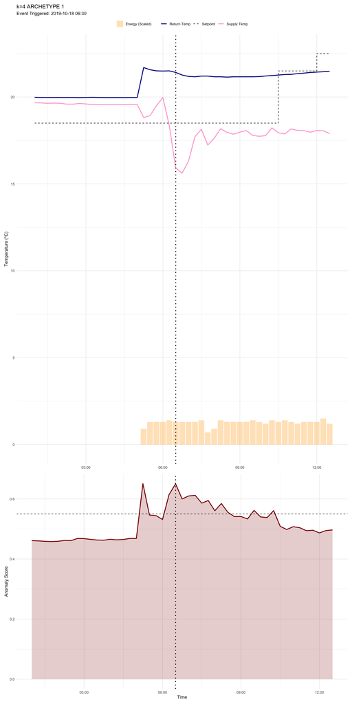

```r
# 1. Force the k=4 cut
extreme_events_k4 <- hvac_scored %>%
  filter(anomaly_score > 0.6) %>%
  mutate(
    matrix_idx = row_number(),
    cluster = as.factor(cutree(hc_tree, k = 4))
  )

# 2. Re-use the medoid extraction logic
get_k4_medoid <- function(target_cluster) {
  cluster_indices <- extreme_events_k4 %>%
    filter(cluster == target_cluster) %>%
    pull(matrix_idx)

  sub_matrix <- mdtw_dist_matrix[cluster_indices, cluster_indices]
  medoid_local_idx <- which.min(rowSums(sub_matrix))

  medoid_global_idx <- cluster_indices[medoid_local_idx]
  return(extreme_events_k4$timestamp[medoid_global_idx])
}

arch_k4_1 <- get_k4_medoid(1)
arch_k4_2 <- get_k4_medoid(2)
arch_k4_3 <- get_k4_medoid(3)
arch_k4_4 <- get_k4_medoid(4)

# 3. Visualize the four Archetypes
plot_k4_1 <- plot_blast_radius(arch_k4_1, "k=4 ARCHETYPE 1")
plot_k4_2 <- plot_blast_radius(arch_k4_2, "k=4 ARCHETYPE 2")
plot_k4_3 <- plot_blast_radius(arch_k4_3, "k=4 ARCHETYPE 3")
plot_k4_4 <- plot_blast_radius(arch_k4_4, "k=4 ARCHETYPE 4")

# Print sequentially for Quarto rendering
plot_k4_1
```

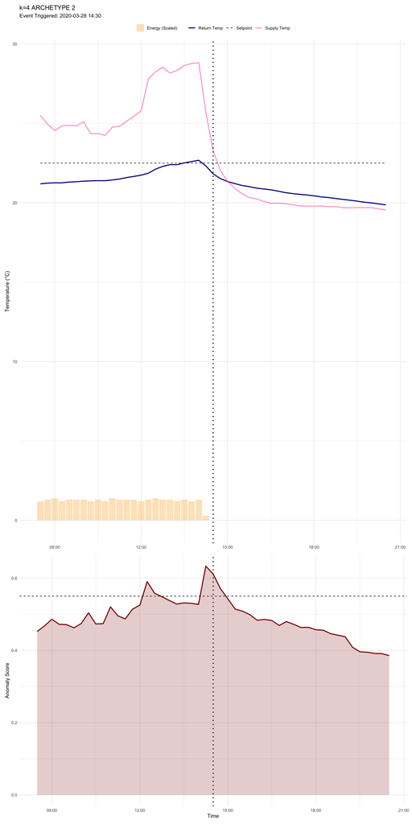

```r
plot_k4_2
```

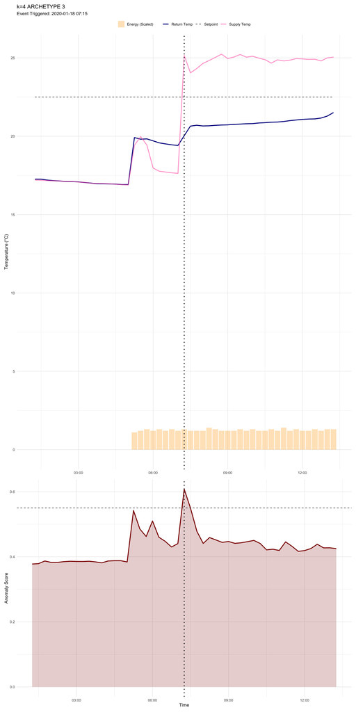

```r
plot_k4_3
```

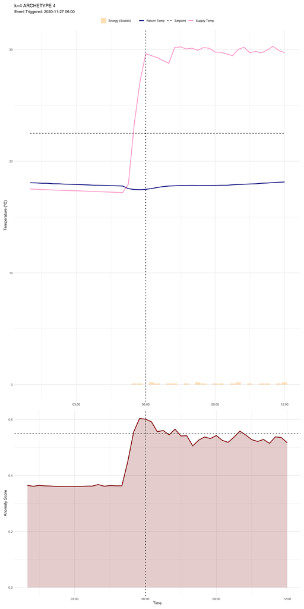

```r
plot_k4_4
```

2026 Joël R. Pradines.

## References

Dekker, Rommert. 1996. “Applications of Maintenance Optimization Models: A Review and Analysis.” *Reliability Engineering & System Safety* 51 (3): 229–40.

Kelley Jr, James E, and Morgan R Walker. 1959. “Critical-Path Planning and Scheduling.” *IRE Transactions on Engineering Management*, no. 3: 160–73.

Nicolai, Robin P, and Rommert Dekker. 2008. “Optimal Maintenance of Multi-Component Systems: A Review.” In *Complex System Maintenance Handbook*. Springer.

Rubinstein, Reuven Y, and Dirk P Kroese. 2016. *Simulation and the Monte Carlo Method*. John Wiley & Sons.